# Assignment Prediction Model

Manousos Emmmanouil Theodosiou [6686311], Group: GG Force

11-01-2021

```r
library(MASS)
library(class)
library(ISLR)
library(tidyverse)
```

```r
library(rpart)
library(rpart.plot)
library(randomForest)
```

Load the dataset “accidents_2012_to_2014.csv”

```r
accidents <-
  read_csv("accidents_2012_to_2014.csv")
#View(accidents)

#distinct(accidents, Road_Type)
#distinct(accidents, Weather_Conditions)
#distinct(accidents, Light_Conditions)
#distinct(accidents, Road_Surface_Conditions)
#distinct(accidents, Special_Conditions_at_Site)
#distinct(accidents, Carriageway_Hazards)
```

By looking at the dataset it can be seen that in 2012-2014 the most accidents occur on Saturday whereas the least number of accidents take place on Monday. (1 is Monday, 2 is Tuesday, etc).

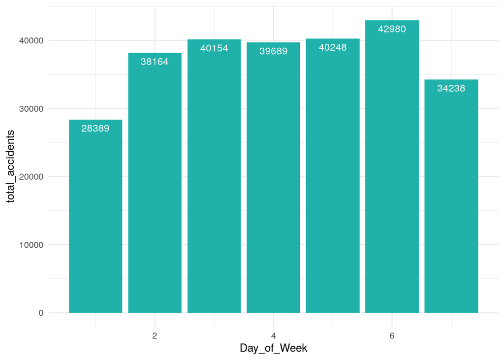

```r
accidents %>%
  group_by(Day_of_Week) %>%
  summarize(total_accidents=n_distinct(Accident_Index)) %>%
    ggplot(aes(x=Day_of_Week, y=total_accidents)) +
    geom_bar(stat="identity", fill="light seagreen")+
    geom_text(aes(label=total_accidents), vjust=1.6, color="white", size=3.5)+
    theme_minimal()
```

We can also visualise the number of accidents by hour. We can see that most accidents take place around 5pm and 8am. This could make sense since people having 9 to 5 jobs are more likely to have an accident on their way to or from their jobs.

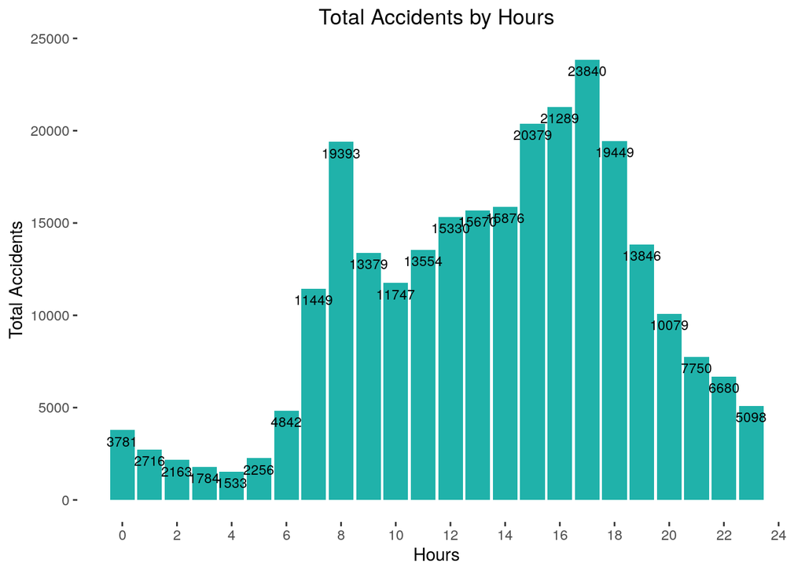

```r
accidents %>%
  mutate(time_slot = as.numeric(substr(Time,0,2))) %>%
  group_by(time_slot) %>%
  summarize(total_accidents=n_distinct(Accident_Index)) %>%
    ggplot(aes(x=time_slot, y=total_accidents)) +
    geom_bar(stat="identity", fill="light seagreen")+
    geom_text(aes(label=total_accidents), vjust=1.6, color="black", size=3)+
    scale_x_continuous(breaks = round(seq(0, 24, by = 2),0)) +
    ggtitle("Total Accidents by Hours") +
    xlab("Hours") + ylab("Total Accidents")+
    theme(plot.title = element_text(hjust = 0.5), panel.background = element_blank())
```

Here, we will analyse the probability of having an accident (1 for Fatal, 2 for Serious, 3 for Slight) in a given hour.

```r
accidents_time <-
  accidents %>%
  mutate(time_slot = as.numeric(substr(Time,0,2)))

accidents_time_severity <- table(accidents_time$time_slot, accidents_time$Accident_Severity)
prop.table(accidents_time_severity,1)
```

```
##
##                1           2           3
##   0  0.024660912 0.193279901 0.782059186
##   1  0.027365295 0.198345354 0.774289351
##   2  0.027527792 0.215987295 0.756484913
##   3  0.035087719 0.212759171 0.752153110
##   4  0.033788914 0.190964313 0.775246773
##   5  0.030287860 0.186733417 0.782978723
##   6  0.016501269 0.161435495 0.822063236
##   7  0.010392666 0.138536203 0.851071131
##   8  0.005421950 0.115201866 0.879376184
##   9  0.008179352 0.120867944 0.870952704
##   10 0.012230988 0.137061762 0.850707250
##   11 0.011454707 0.133287461 0.855257832
##   12 0.008774781 0.134004983 0.857220236
##   13 0.010484363 0.135614520 0.853901117
##   14 0.009860953 0.139720488 0.850418558
##   15 0.009607398 0.143086550 0.847306052
##   16 0.009631878 0.144372609 0.845995514
##   17 0.009104668 0.137492314 0.853403018
##   18 0.009172923 0.145101720 0.845725357
##   19 0.012288136 0.150762712 0.836949153
##   20 0.011418584 0.158461987 0.830119429
##   21 0.014671048 0.167112402 0.818216551
##   22 0.020226108 0.171524466 0.808249426
##   23 0.022077620 0.176504764 0.801417616
```

```r
View(accidents_time)
```

Now we will choose only the relevant predictors for the response variable Accident_Severity and make a dataframe.

```r
variables <- names(accidents_time) %in% c("Accident_Severity",
                                 "Number_of_Vehicles",
                                 "Number_of_Casualties",
                                 "Day_of_Week",
                                 "time_slot",
                                 "Road_Type",
                                 "Speed_limit",
                                 "Light_Conditions",
                                 "Weather_Conditions",
                                 "Road_Surface_Conditions"
                                 )

accidents_df <- data.frame(accidents_time[variables])
View(accidents_df)
```

Check the type of each column by running the sapply() function.

```r
sapply(accidents_df, class)
```

```
##       Accident_Severity      Number_of_Vehicles    Number_of_Casualties
##               "numeric"               "numeric"               "numeric"
##             Day_of_Week               Road_Type             Speed_limit
##               "numeric"             "character"               "numeric"
##        Light_Conditions      Weather_Conditions Road_Surface_Conditions
##             "character"             "character"             "character"
##               time_slot
##               "numeric"
```

Using all predictors:

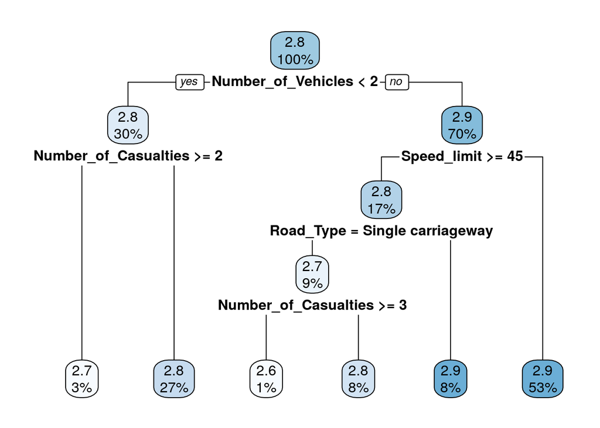

```r
set.seed(1)
accidents_tree_mod <- rpart(Accident_Severity ~ ., data = accidents_df,
                            control=rpart.control(minsplit=10, cp=0.001))
rpart.plot(accidents_tree_mod)
```

Using Accident_Severity ~ Road_Type + Light_Conditions + Weather_Conditions + Road_Surface_Conditions:

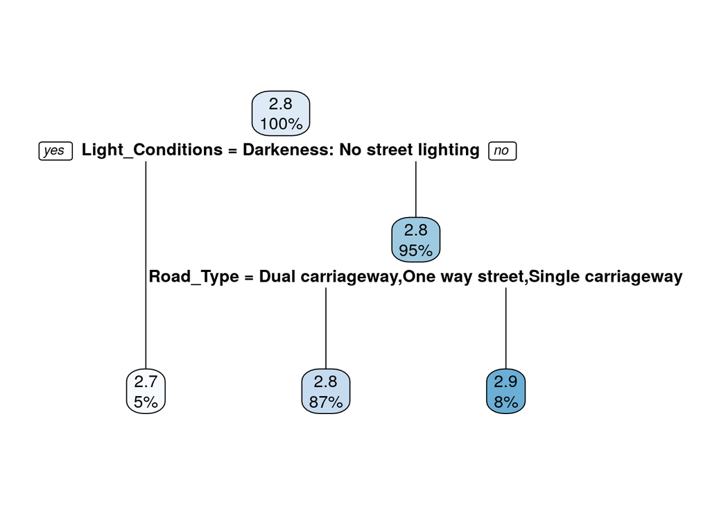

```r
set.seed(1)
accidents_tree_mod_1 <- rpart(Accident_Severity ~ Road_Type + Light_Conditions
                              + Weather_Conditions + Road_Surface_Conditions,
                              data = accidents_df,
                              control=rpart.control(minsplit=10, cp=0.001))
rpart.plot(accidents_tree_mod_1)
```

## Random Forest for classification (RUNS OUT OF MEMORY)

```r
#accidents_rf <- randomForest(Accident_Severity ~ ., data = accidents_df, importance = TRUE)
#accidents_rf
```

Importance

```r
#importance(accidents_rf)
```

Plot importance

```r
#varImpPlot(accidents_rf)
```